[figure not shown]

**22. San Francisco, CA.**  
I've only been programming for a year, but it already feels like a lifetime. Palautatan means "statistics" in Tagalog.  
View Home Page | [View My GitHub Profile](https://github.com/palautatan)

# Final Project, Problem 1

# The Student Dataset

The student dataset `student.csv` contains 8 measurements for 200 student subjects. These students either are male or female, went to private or public school, all received scores for the subjects of reading, writing, math, and science, were in an honors program or not, and have had their family’s socioeconomic status recorded.

Displayed below are a mosaic plot of the categorical data of students with high socioeconomic status and histograms of their corresponding scores. Attached in Appendix A are the figures for students with low and medium socioeconomic status (SES).

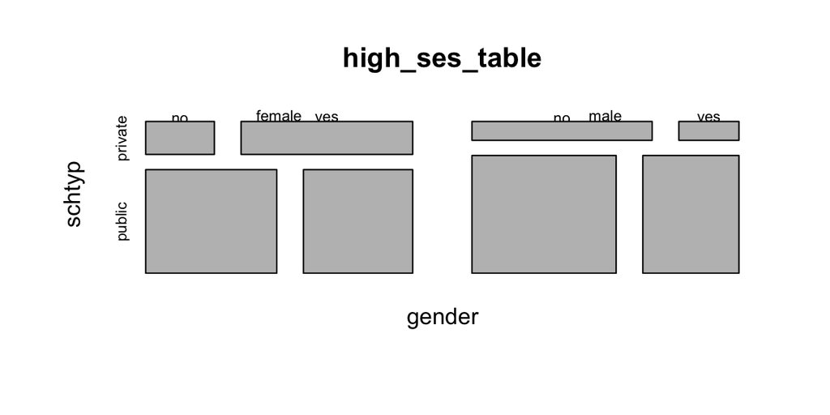

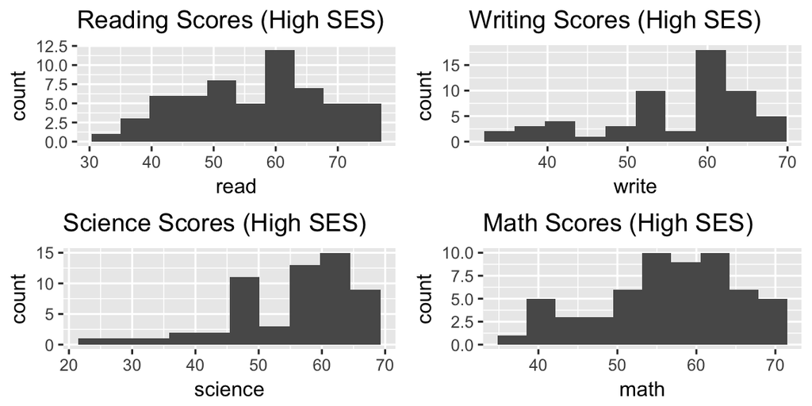

For all students, we see that more females are in honors programs. As SES decreases, there is an obvious decrease in amount of students participating in honors programs. Both high and middle SES students have a similar distribution of public/private school students, there being far more public school enrollees than private school students. Low SES students hardly are enrolled in private schools, but if they are, then they are more likely to be female than male. In contrast with the distribution of the categorical variables (gender, school type, honors program status) for students with low and medium SES, we see that there are more honors program students overall for high SES students. Unsurprisingly, the score histograms for high SES students are left-skewed, and students outperform medium and low SES in subject scores.

# Fitting the Model

Our goal in creating a model to `student.csv` is to predict socioeconomic status from a student’s sex, school type, and subject scores. In order to fit a model optimal for prediction to `students`, we used Backward-Forward Model Selection using AIC as our criterion.

The best fit model was SES ~ gender + schtyp + read + honors with the following estimated coefficients with and AIC of 403.7529. This model had the lowest AIC as a result of the Backward-Forward Model Selection procedure.

```
##        (Intercept) gendermale schtyppublic        read  honorsyes
## low       2.644419 -0.8675304    1.6367326 -0.07403496 -0.2937044
## middle    2.304598 -0.1910837   -0.0462631 -0.02470590 -1.1706580
```

Our multinomial logistic regression model is: $\pi(\vec{X})=\alpha + \beta_1X^{gender} + \beta_2X^{schtyp} + \beta_3X^{read} + \beta_4X^{honors}$.

We can also interpret the following from the above model.

The relative probability of being in low SES is $exp(-0.8675304)=0.4199875$ times that of being in high SES for a male student versus a female student, all other variables being held constant.

The relative probability of being in middle SES is $exp(-0.1910837)=0.8260634$ times that of being in high SES for a male student versus a female student, all other variables being held constant.

The relative probability of being in low SES is $exp(1.6367326)=5.138353$ times that of being in high SES for a public school student versus a private school student, all other variables being held constant.

When a specific student’s reading score increases by 1, the probability of being in low SES is $exp(-0.07403496)=0.9286392$ times that of high SES, with all other variables held constant.

When a specific student’s reading score increases by 1, the probability of being in middle SES is $exp(-0.02470590)=0.9755968$ times that of high SES, with all other variables held constant.

The relative probability of being in low SES is $exp(-0.2937044)=0.7454968$ times that of being in high SES for an honors student versus a non-honors student, all other variables being held constant.

The relative probability of being in middle SES is $exp(-1.1706580)=0.3101628$ times that of being in high SES for an honors student versus a non-honors student, all other variables being held constant.

# Diagnostics

We will perform diagnostics on our multinomial logistic model to identify outliers and other influential points. Then, we will assess the predictive power of our model.

## Diagnostics for Low to High Relative Model

**Standardized Residuals** If our model fits our data well, then the residuals should be distributed as standard normal.

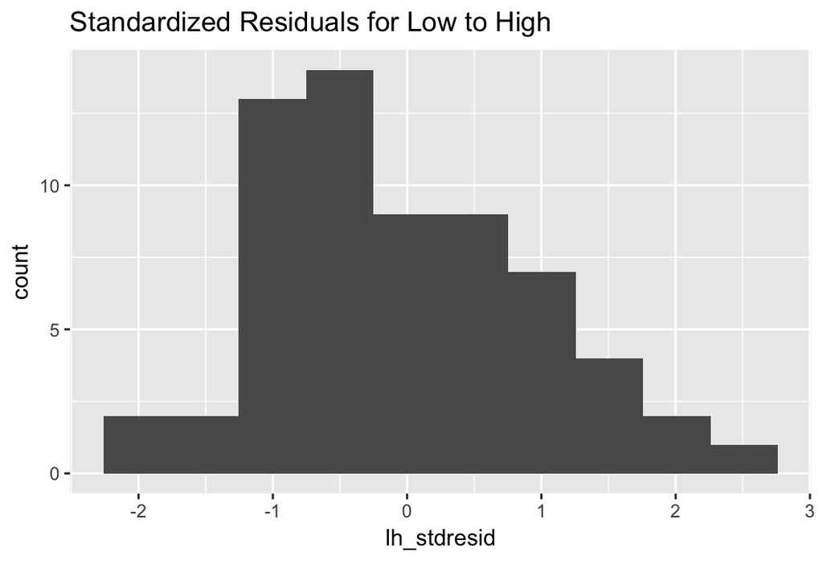

```
## Mean:  -0.03653888
## Variance:  0.9581778
```

**Dfbeta** Using Dfbeta with a threshold of 0.2, we were able to find that the following observations were influential:

```
##    (Intercept) gendermale schtyppublic read honorsyes y     dBhat
## 1:           1          0            0   36         0 0 0.2388299
## 2:           1          0            0   60         0 1 0.7502532
```

**Proportional Reduction in Squared Error** Our value of Proportional Reduction in Squared Error is $0.2099446<<1$. This suggests that when we add our X variables to our model, the predictive power does not significantly change from the baseline $\bar{y}$. Even though we used Backward-Forward model selection with AIC, it is apparent that our best model has low predictive power.

```
## [1] 0.2099446
```